# Hypothesentests mittels (Re-)Sampling

Prof. Dr. Jörg Schoder

2023-05-29

# Beispiel: Geschlechterdiskriminierung am Arbeitsplatz

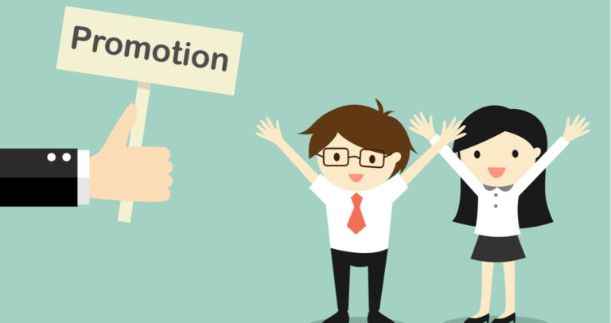

Bildquelle: [fullonapp.com](https://fullonapp.com/learn-how-to-get-promoted-at-your-job-with-these-10-basic-points/)

### Studiendesign

- Daten aus einer 1974 im Journal of Applied Psychology veröffentlichten Studie
- Studiendesign:
  - 48 Bankaufsichtsbeamte sollten die Rolle eines hypothetischen Direktors einer Bank mit mehreren Filialen übernehmen.
  - Allen Probanden wurde ein Lebenslauf vorgelegt und die Frage gestellt, ob der Kandidat auf dem Lebenslauf für eine neue Position in einer ihrer Filialen geeignet sei oder nicht.
  - Die 48 Lebensläufe waren jedoch in jeder Hinsicht identisch, mit einer Ausnahme: dem Namen des Bewerbers.
    - 24 Vorgesetzte erhielten zufällig Lebensläufe mit typisch “männlichen” Namen
    - 24 Vorgesetzten erhielten zufällig Lebensläufe mit typisch “weiblichen” Namen
  - Weil sich die Lebensläufe nur hinsichtlich des (binären) Geschlechts unterscheiden, kann auf Basis der Daten ein kausaler Zusammenhang des Geschlechts im Sinne eines Experiments untersucht werden.

### Daten

- Tabelle mit sechs zufälligen Beobachtungen:

```r
library(moderndive)
set.seed(13)
promotions %>%
  sample_n(size = 6) %>%
  arrange(id)
```

```
## # A tibble: 6 × 3
##      id decision gender
##   <int> <fct>    <fct>
## 1     3 promoted male
## 2     6 promoted male
## 3    10 promoted male
## 4    13 promoted male
## 5    24 promoted female
## 6    37 not      male
```

- Explorative Datenanalyse
  - Datenvisualisierung mittels Balkendiagramm

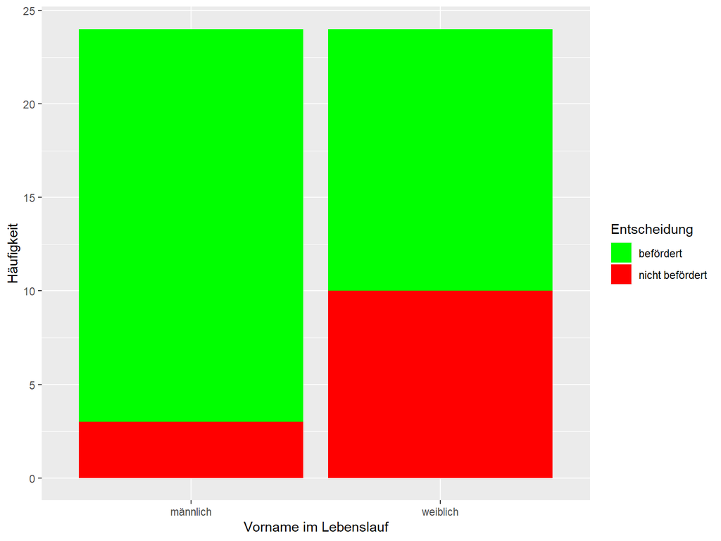

```r
p <- promotions %>%
        mutate(gender=if_else(gender=='female','weiblich','männlich'),
               decision=if_else(decision=='promoted','befördert','nicht befördert')) %>%
        ggplot(aes(x = gender, fill = decision)) +
        geom_bar() + scale_fill_manual(values = c("green", "red")) +
        labs(x = "Vorname im Lebenslauf",fill='Entscheidung',y='Häufigkeit')
p
```

* Kennzahlen

```
## # A tibble: 4 × 3
## # Groups:   gender [2]
##   gender decision     n
##   <fct>  <fct>    <int>
## 1 male   not          3
## 2 male   promoted    21
## 3 female not         10
## 4 female promoted    14
```

Während also 87.5% der Männer befördert wurden, waren es bei den Frauen lediglich 58.3%. Mithin betrug der Unterschied in der Beförderung zwischen den Geschlechtern 29.2%.

Damit stellt sich eine typische Frage der statistischen Inferenz: Kann aus dem beobachteten Unterschied auf eine geschlechtsspezifische Diskriminierung bei Beförderungen in Banken geschlossen werden?

Oder könnte ein Unterschied bei den Beförderungsquoten von 29.2% auch in einer (hypothetischen) Welt, in welcher es keine geschlechtsspezifische Diskriminierung gibt, **zufällig auftreten**?

Zur Beantwortung der Frage können wir die Stichprobenvariation (in der hypothetischen Welt) nutzen.

# Nullhypothese: Welt ohne Diskriminierung

- In einer diskriminierungsfreien Welt wäre die Variable `Geschlecht` ohne Bedeutung für die Entscheidung über eine Beförderung.
- Wir könnten die Variable `Geschlecht` “neu mischen” und zufällig auf die Stichprobe verteilen, ohne etwas zu verändern.

[figure not shown]

Beispiel einer “Mischung” der Variable “Geschlecht”

| Lebenslauf Nr. | Entscheidung | Geschlecht | Geschlecht permutiert |
| --- | --- | --- | --- |
| 1 | nicht | männlich | männlich |
| 2 | nicht | weiblich | männlich |
| 3 | nicht | weiblich | weiblich |
| 4 | befördert | männlich | weiblich |
| 5 | befördert | männlich | weiblich |
| 6 | befördert | weiblich | männlich |

Das Objekt `promotions_shuffled` enthält die eine Permutation der Variable `Geschlecht` und zeigt ein Beispiel (eine Ziehung), wie die Anteile der Beförderungen beider Geschlechter bei zufälliger Zuordnung des Geschlechts verteilt sein könnten (vgl. Balkendiagramm). Die “Mischung” erfolgte dabei in einer diskriminierungsfreien Welt, d.h. für die gültige $H_0$.

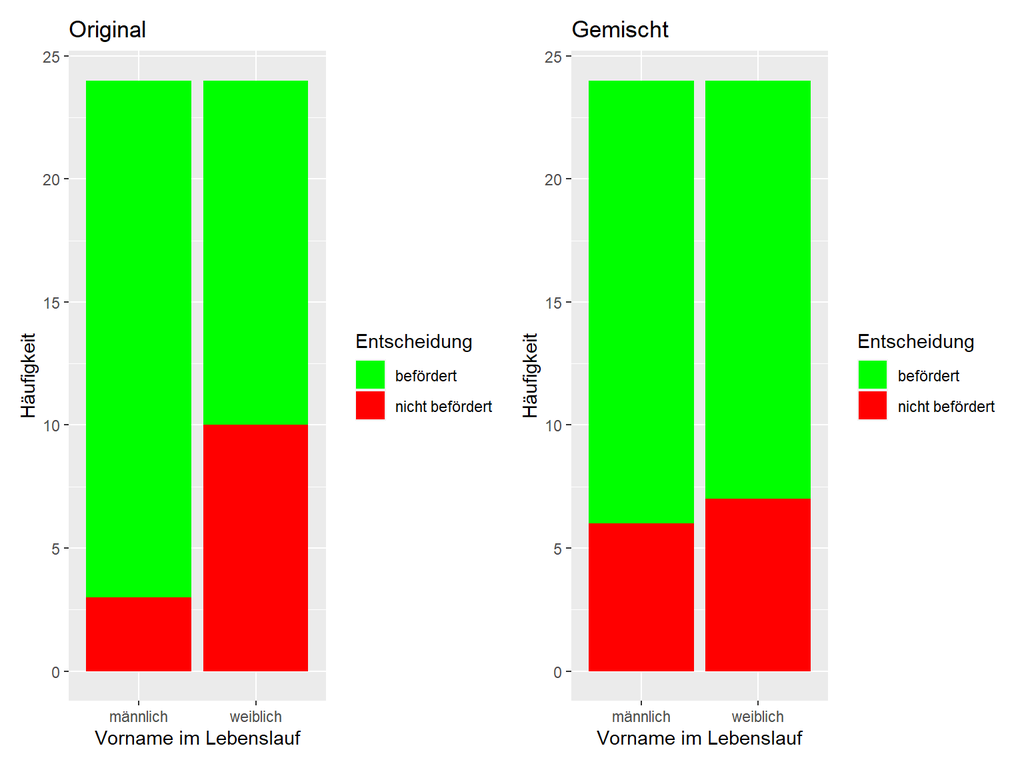

- Kennzahlen

```
## # A tibble: 4 × 3
## # Groups:   gender [2]
##   gender decision     n
##   <fct>  <fct>    <int>
## 1 male   not          6
## 2 male   promoted    18
## 3 female not          7
## 4 female promoted    17
```

In der hypothetischen Welt, in der “Geschlecht” ein *unbedeutendes label* ist, wären also 75% der Männer befördert wurden, waren es bei den Frauen lediglich 70.8%. Mithin wäre der Unterschied in der Beförderung zwischen den Geschlechtern nun mit 4.2% deutlich geringer als in der Original-Stichprobe.

Die unterschiedliche Differenz der geschlechtsspezifischen Beförderungsquoten ist ein weiteres Beispiel für **Stichproben-Variation**.

# Wiederholtes Mischen (Permutation)

- Die Autoren von [moderndive](https://moderndive.com/9-hypothesis-testing.html#understanding-ht) Freunde darum, die “Mischübung” zu wiederholen.
- Die Ergebnisse von 16 Gruppen wurden in einem gemeinsamen [GoogleSheet](https://docs.google.com/spreadsheets/d/1Q-ENy3o5IrpJshJ7gn3hJ5A0TOWV2AZrKNHMsshQtiE/edit?pli=1#gid=0) festgehalten. Hier ein Ausschnitt:

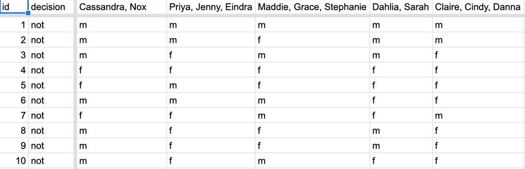

Ausschnitt GoogleSheets

### Erzeugung einer Stichprobenverteilung mittels Permutation

- Die Stichprobenverteilung dieser 16-fach wiederholten Mischübung (**Permutation**) stellt sich wie folgt dar:

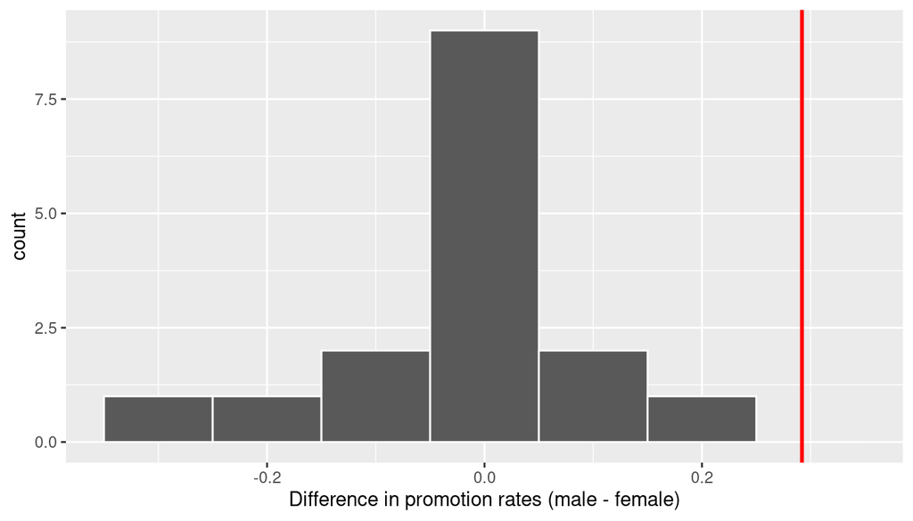

Verteilung bei 16-facher Permutation

- Das Histogramm stellt die Differenz zwischen den geschlechtsspezifischen Beförderungsquoten in einer hypothetischen diskriminierungsfreien Welt dar.
  - Die Diskriminierungsfreiheit zeigt sich in der Stichprobenverteilung in der Zentrierung um Null herum
  - Obwohl die Werte um Null liegen, gibt es dennoch Abweichungen - selbst in der hypothetischen Welt sind in Zufallsstichproben immer noch kleine, **zufällige** Unterschiede bei den Beförderungsraten zu erwarten.
  - Tatsächlich zeigen sich im Histogramm durchaus größere Unterschiede von bis zu -0,292 oder 0,208.
- Die rote Linie stellt den Unterschied der Beförderungsquoten aus der Original-Stichprobe (29,2%) dar. Wie wahrscheinlich wäre es, dass wir in einer hypothetischen Welt ohne Geschlechterdiskriminierung diesen Unterschied beobachten?

Die in der Original-Stichprobe von 48 Lebensläufen Geschlechter-Unterschiede sind mit der *(Null-)Hypothese einer diskriminierungsfreien Welt* **kaum vereinbar**. Es spricht viel dafür, die Null-Hypothese zu verwerfen und festzustellen, dass die Daten auf eine geschlechtsspezifische Diskriminierung hindeuten.

### Permutation vs. Bootstrapping

- Bootstrapping: Ziehen aus den Stichproben-Daten mit Zurücklegen
- **Permutation**: Ziehen aus den Stichproben-Daten **ohne** Zurücklegen

# Permutation als Teststrategie (Permutationstests)

- Indem wir die geschlechtsspezifischen Unterschiede in den Beförderungsquoten ($p_m-p_f$) untersucht haben, haben wir ein Beispiel für Fall 3 aus der bereits bekannten Tabelle betrachtet:

Mögliche Punktschätzer auf Basis von Stichproben

| Fall | Parameter der Grundgesamtheit | Notation | Punktschätzung | Symbol(e) |
| --- | --- | --- | --- | --- |
| 1 | Anteil in Grundgesamtheit | $p$ | Anteil in Stichprobe | $\widehat{p}$ |
| 2 | Mittelwert der Grundgesamtheit | $\mu$ | Stichprobenmittelwert | $\overline{x}$ oder $\widehat{\mu}$ |
| 3 | Differenz von Anteilen einer Grundgesamtheit | $p_1 - p_2$ | Differenz von Anteilen einer Stichprobe | $\widehat{p}_1 - \widehat{p}_2$ |
| 4 | Differenz von Mittelwerten der Grundgesamtheit | $\mu_1 - \mu_2$ | Differenz von Stichprobenmittelwerten | $\overline{x}_1 - \overline{x}_2$ oder $\widehat{\mu}_1 - \widehat{\mu}_2$ |
| 5 | Empirischer Regressionskoeffizient (Grundgesamtheit) | $\beta_1$ | Angepasster (“fitted”) Regressionskoeffizient (Stichprobe) | $b_1$ oder $\widehat{\beta}_1$ |

- Ausgehend von unserer Stichprobe mit $n_m=24$ “männlichen” und $n_w=24$ “weiblichen” BewerberInnen ist der **Punktschätzer** für $p_m-p_f$ also die Differenz der Stichprobenanteile $\hat{p_m}-\hat{p_f}= 0,875 - 0,583 = 0,292 = 29,2%$. Diese Differenz zugunsten der “männlichen” Lebensläufe von 0,292 ist größer als 0, was auf eine Diskriminierung zugunsten der Männer hindeutet.
- Daher stellten wir uns ursprünglich die folgende Frage: “Ist der Unterschied signifikant größer als 0? Mit anderen Worten, ist dieser Unterschied ein Hinweis auf eine echte Diskriminierung, oder können wir ihn nur auf Stichprobenschwankungen zurückführen?

Hypothesentests erlauben uns (unter anderem) solche Unterscheidungen zwischen zufälligen und “über-zufälligen” Differenzen zwischen Gruppen zu treffen!

# Hypothesentests und Begrifflichkeiten

- **Hypothese** als Aussage über den Wert eines unbekannten Populationsparameters.
  - Hypothesentests können sich auf jeden der Populationsparameter in der obigen Tabelle der fünf Inferenzszenarien beziehen.
  - In unserem Beispiel Geschlechterunterschieden bei der Beförderung interessieren wir uns für Differenz der Populationsanteile $p_m-p_f$ als **Parameter der Grundgesamtheit**.
- **Hypothesentest** als Test zwischen zwei **konkurrierenden Hypothesen**: (1) einer Nullhypothese $H_0$ (ausgesprochen “H-Null”) und (2) einer Alternativhypothese $H_A$.
  - Im Allgemeinen ist $H_0$ eine Behauptung, dass es “keinen Effekt” oder “keinen Unterschied von Interesse” gibt.
  - Demgegenüber ist die Alternativhypothese in der Regel eine Behauptung, die der Wissenschaftler aufstellt und für die er Belege finden möchte (“Herausforderer”-Hypothese zur $H_0$) betrachtet.
  - In unserem Beispiel zu Geschlechtsunterschieden bei Beförderungen:
    - $H_0$: Männer und Frauen werden in gleichem Maße befördert vs.
    - $H_A$: Männer werden in höherem Maße befördert als Frauen (einseitiger Test)
    - oder $H_A$: es gibt einen Unterschied in der Beförderung zwischen den Geschlechtern (zweiseitiger Test)
    - Kurz (im Fall des einseitigen Tests):
      - $H_0$: $p_m-p_f=0$ vs.
      - $H_A$: $p_m-p_f>0$
- **Teststatistik** als Punktschätzung bzw. zusammenfassende Stichprobenstatistik.
  - basiert auf einer Stichprobe von Beobachtungen
  - kondensiert viele Werte zu einem Wert.
  - **Im Beispiel:** Stichproben von $n_m=24$ Lebensläufen mit männlichen Namen und $n_f=24$ Lebensläufen mit weiblichen Namen. Differenz der Stichprobenanteile $\hat{p_m}-\hat{p_f}$ als **interessierende Punktschätzung**.
- **Beobachtete** Teststatistik: der Wert der Teststatistik, den wir in der Realität (Stichprobe) beobachtet haben. Im Beispiel: $\hat{p_m}-\hat{p_f}= 0,875 - 0,583 = 0,292 = 29,2%$
- Die **Nullverteilung**: Stichprobenverteilung der Teststatistik **unter der Annahme**, dass die Nullhypothese $H_0$ wahr ist.
  - Wie verändert sich die Teststatistik aufgrund von Stichprobenvariationen?
  - Im Beispiel: Wie verändert sich der Unterschied in den Stichprobenanteilen $\hat{p_m}-\hat{p_f}$ aufgrund der Stichproben-Variation unter $H_0$?

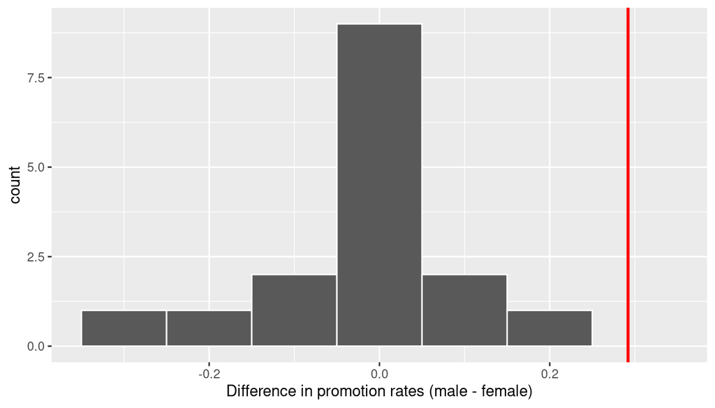

Nullverteilung

- **p-Wert** als Wahrscheinlichkeit, bei gültiger $H_0$ eine Teststatistik zu erhalten, die genauso extrem oder noch extremer als die beobachtete Teststatistik ist
  - p-Wert als Quantifizierung der “Überraschung”: Angenommen, H0 ist wahr, wie überrascht sind wir von dem, was wir beobachtet haben?
  - Im Beispiel: wie überrascht sind wir im hypothetischen Universum ohne geschlechtsspezifische Diskriminierung, dass die gesammelten Daten einen Unterschied in den Beförderungsraten von 0,292 anzeigen?
  - “Extrem” im Sinne der Alternativhypothese $H_A$: “männliche” werden Bewerber häufiger befördert als “weibliche” Bewerber. In diesem Fall haben wir in 0 von 16 Fällen einen Unterschied im Anteil erhalten, der größer oder gleich dem beobachteten Unterschied von 0,292 = 29,2 % ist. Ein sehr seltenes (in der Tat nicht vorkommendes) Ergebnis!
  - Bei sehr seltenen Überraschungen (kleinen p-Werten) wird die $H_0$ üblicherweise zugunsten von $H_A$ verworfen.
- Das **Signifikanzniveau** $\alpha$ sollte bei Hypothesentests **Vorab** festgelegt werden.
  - $\alpha$ dient als Grenzwert für den $p-Wert$. Wenn der p-Wert unter $\alpha$ fällt, wird die Nullhypothese $H_0$ abgelehnt.
  - übliche Werte für $\alpha$: 0,1, 0,01 und **0,05**.
  - Wenn der p-Wert nicht unter $\alpha$ fällt, würde $H_0$ nicht zurückgewiesen.

Kritischer Rationalismus (K. Popper): Die $H_0$ nicht abzulehnen, heißt nicht, sie zu akzeptieren!

# Exkurs: p-Hacking

### Comedy

[video not shown]

[John Oliver P-Hacking](https://www.youtube.com/watch?v=FLNeWgs2n_Q)

### Akademischer und ausführlicher (mehrere Teile)

[video not shown]

[Jeff Galak](https://www.youtube.com/watch?v=eqrv-Lq4a5E&list=PLmXNcJ-VjBYooRTlv91jS479PcnK-6zsN)

### Prinzipien ASA

Die [ASA (2016)](https://www.amstat.org/asa/files/pdfs/P-ValueStatement.pdf) hat folgende Grundsätze herausgegeben, die sich u.a. auf Missverständnisse und Missbrauch des $p$-Wertes beziehen:

1. $p$-Werte können angeben, wie unvereinbar die Daten mit einem bestimmten statistischen Modell sind.
2. $p$-Werte messen nicht die Wahrscheinlichkeit, dass die untersuchte Hypothese wahr ist, oder die Wahrscheinlichkeit, dass die Daten allein durch Zufall entstanden sind.
3. Wissenschaftliche Schlussfolgerungen und unternehmerische oder politische Entscheidungen sollten nicht allein darauf beruhen, dass ein $p$-Wert einen bestimmten Schwellenwert überschreitet.
4. Korrekte Schlussfolgerungen erfordern eine umfassende Berichterstattung und Transparenz.
5. Ein $p$-Wert oder eine statistische Signifikanz ist **kein Maß für die Größe eines Effekts** oder die Bedeutung eines Ergebnisses.
6. Ein $p$-Wert an sich ist kein gutes Maß für die Evidenz eines Modells oder einer Hypothese.

Im Vordergrund eines umfassenden Ergebnisberichts sollte die Effektstärke stehen. Ergänzend sollte die Einschätzung der statistischen Signifikanz eines Effekts mit dem $p$-Wert erfolgen.

# Hypothesentests mit dem **infer**-Paket

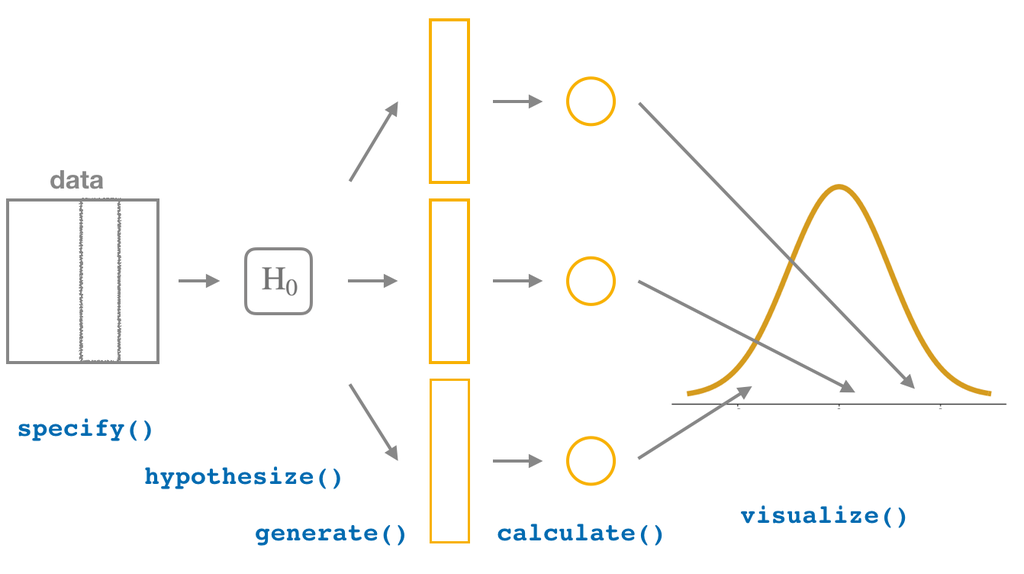

Workflow Hypothesentest mit infer-Paket

Verglichen mit dem infer-workflow zur Konstruktion von Konfidenzintervallen:

- ein zusätzlicher Schritt: `hypothesize()` zur Formulierung der Hypothesen
- Festlegung des Signifikanzniveaus (default: $\alpha=.05$)

### `specify()`

- Spezifikation der abhängigen Variable (*response*) und der unabhängigen/erklärenden (*explanatory*) Variable(n):

> formula = response ~ explanatory
- Im Beispiel: Wir wollen den Effekt des Geschlechts auf die Entscheidung über Beförderungen untersuchen.
  - *response* ist also die Variable “Beförderungsentscheidung” (`decision`).
  - *explanatory* ist die Variable “Geschlecht” (`gender`). Mehrere unabhängige Variablen können ggf. mittels `+` verknüpft werden.
  - Bei `decision` handelt es sich um eine binäre/dichotome Variable (auch: Dummy-Variable) mit zwei Ausprägungen: “promoted” vs. “not”. Wir interessieren uns für die dokumentierten Beförderungen (Option *success = “promoted”*)

```r
library(infer)
promotions %>%
  specify(formula = decision ~ gender, success = "promoted")
```

```
## Response: decision (factor)
## Explanatory: gender (factor)
## # A tibble: 48 × 2
##    decision gender
##    <fct>    <fct>
##  1 promoted male
##  2 promoted male
##  3 promoted male
##  4 promoted male
##  5 promoted male
##  6 promoted male
##  7 promoted male
##  8 promoted male
##  9 promoted male
## 10 promoted male
## # ℹ 38 more rows
```

Die Daten selbst werden lediglich “wiederholt” bzw. unverändert dargestellt. Jedoch ändern sich die Metadaten: Die Variablen werden als `Response` bzw. `Explanatory` kategorisiert.

### `hypothesize()`

- Formulierung von $H_0$ und $H_A$.
- Im Beispiel:
  - $H_0$: $p_m-p_f=0$ vs.
  - $H_A$: $p_m-p_f>0$
- Festlegung der $H_0$ in der `hypothesize()`-Funktion, die zusätzlich folgende Optionen enthält:
  - `point` für Tests im Einstichprobenfall (bspw. Wochenarbeitszeit 40 Stunden (oder nicht))
  - `independence` für Tests im Zwei-Stichprobenfall
- Im Beispiel handelt es sich um einen Zwei-Stichprobenfall. Lebensläufe mit weiblichen vs. männlichen Namen. Entsprechend:

```r
promotions %>%
  specify(formula = decision ~ gender, success = "promoted") %>%
  hypothesize(null = "independence")
```

```
## Response: decision (factor)
## Explanatory: gender (factor)
## Null Hypothesis: independence
## # A tibble: 48 × 2
##    decision gender
##    <fct>    <fct>
##  1 promoted male
##  2 promoted male
##  3 promoted male
##  4 promoted male
##  5 promoted male
##  6 promoted male
##  7 promoted male
##  8 promoted male
##  9 promoted male
## 10 promoted male
## # ℹ 38 more rows
```

Auch dieser Schritt verändert die Daten selbst nicht. Erneut ändern sich nur die Metadaten: Die Null-Hypothese wird “aufgenommen”.

### `generate()`

```r
promotions_generate <- promotions %>%
                          specify(formula = decision ~ gender, success = "promoted") %>%
                          hypothesize(null = "independence") %>%
                          generate(reps = 1000, type = "permute")
nrow(promotions_generate)
```

```
## [1] 48000
```

Wir erhalten ein **tibble**-Objekt mit 48000 Zeilen: Für jede der 48 Zeilen der Original-Sitchprobe werden 1000 Mischungen/Mutationen durchgeführt.

### `calculate()`

- Die 1000 “Re-Shuffles” wurden unter der Annahme erzeugt, dass die Nullhypothese wahr ist.
- Aus diesen Stichproben berechnen wir nun die **Teststatistik**.
  - Wir interessieren uns für den unbekannten Populationsparameter “Differenz der Populationsanteile” $p_m-p_f$.
  - Folglich berechnen wir als Teststatistik die Differenz der Stichprobenanteile $\hat{p_m}-\hat{p_f}$.
  - Für jede unserer 1000 Mischungen können wir diese Teststatistik mit der Option *stat = “diff in props”* ermitteln.
  - Weil uns $\hat{p_m}-\hat{p_f}$ interessiert, nutzen wir außerdem die Option *order = c(“male”, “female”)*.

Die Reihenfolge der Subtraktion spielt keine Rolle, solange wir im Rahmen der Analyse konsistent bleiben und auch die Interpretationen entsprechend anpassen.

- Im Beispiel speichern wir das Ergebnis in einem **tibble**-Objekt namens null_distribution:

```r
null_distribution <- promotions %>%
                          specify(formula = decision ~ gender, success = "promoted") %>%
                          hypothesize(null = "independence") %>%
                          generate(reps = 1000, type = "permute") %>%
                          calculate(stat = "diff in props", order = c("male", "female"))
null_distribution
```

```
## Response: decision (factor)
## Explanatory: gender (factor)
## Null Hypothesis: independence
## # A tibble: 1,000 × 2
##    replicate    stat
##        <int>   <dbl>
##  1         1 -0.125
##  2         2 -0.0417
##  3         3  0.125
##  4         4 -0.125
##  5         5 -0.0417
##  6         6  0.0417
##  7         7  0.0417
##  8         8  0.0417
##  9         9 -0.125
## 10        10 -0.0417
## # ℹ 990 more rows
```

- Wir erhalten erwartungsgemäß 1000 Anteilswerte für geschlechtsspezifische Differenzen bei der Beförderung. Diese Anteilswerte würden resultieren, wenn die $H_0$ gültig ist.
- Wie hoch war die **beobachtete** Teststatistik $\hat{p_m}-\hat{p_f}$? Die oben berechnete Differenz 0,875 - 0,583 = 0,292 = 29,2% können wir mit der **infer**-Pipe berechnen, wenn wir die Schritte `hypothesize()` und `generate()` weglassen. Speichern wir dies in `obs_diff_prop`:

```r
obs_diff_prop <- promotions %>%
                          specify(formula = decision ~ gender, success = "promoted") %>%
                          calculate(stat = "diff in props", order = c("male", "female"))
obs_diff_prop
```

```
## Response: decision (factor)
## Explanatory: gender (factor)
## # A tibble: 1 × 1
##    stat
##   <dbl>
## 1 0.292
```

### `visualize()`

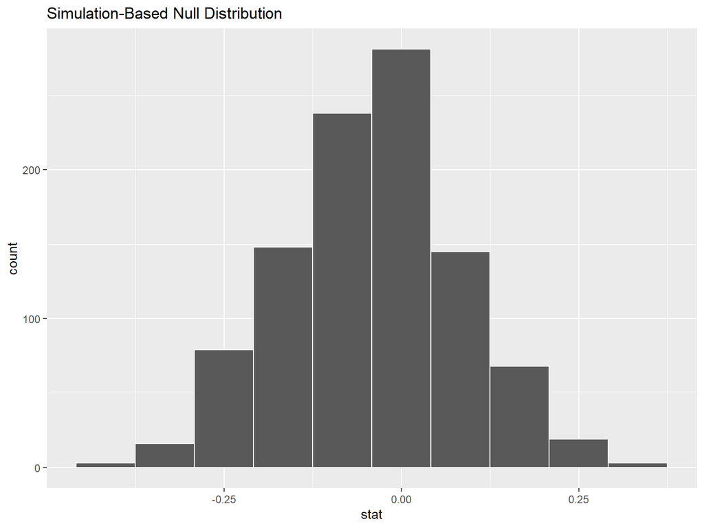

Nullverteilung

```r
visualize(null_distribution, bins = 10)
```

- Das Diagramm kann noch mit Hilfe der noch ergänzt werden:
  - beobachtete Differenz und
  - p-Wert
  - Konfidenzintervalle
- `shade_p_value()` mit den Optionen:
  - **obs_stat** und
  - **direction** mit den Optionen:
    - “less” oder “left”
    - “greater” oder “right”
    - “two-sided” oder “both”

Für unser Beispiel:

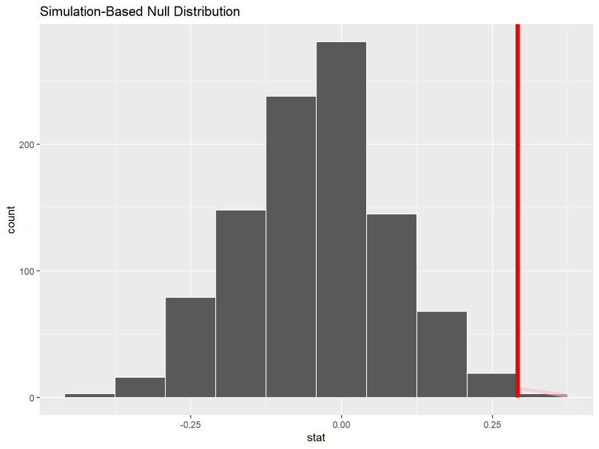

Nullverteilung mit beobachtetem Anteil und p-Wert (schattiert)

```r
visualize(null_distribution, bins = 10) +
  shade_p_value(obs_stat = obs_diff_prop, direction = "right")
```

- Die senkrechte Linie stellt den beobachteten Anteil von 29.2% dar.
- Der schattierte Bereich stellt den p-Wert dar.
  - Interpretation des p-Werts als die Wahrscheinlichkeit, eine Teststatistik zu erhalten, die genauso groß oder größer ist als die beobachtete Teststatistik , wenn $H_0$ wahr ist.
  - Hier: in der hypothetischen Welt ohne geschlechtsspezifische Diskriminierung wären eher selten Unterschiede von 0.292 = 29.2 % oder mehr zu beobachten. Mit anderen Worten, der p-Wert ist eher klein.
  - Mithin würden wir dazu tendieren, die angenommene Grundgesamtheit zu verwerfen. Statistisch ausgedrückt würden wir “$H_0$ verwerfen”.
- Welcher Anteil der Nullverteilung ist schattiert? Mit anderen Worten, was ist der genaue Wert des p-Wertes?

Mit der Funktion `get_p_value()` und denselben Argumenten wie im vorherigen Code shade_p_value() kann der p-Wert berechnet werden:

```r
null_distribution %>%
  get_p_value(obs_stat = obs_diff_prop, direction = "right")
```

```
## # A tibble: 1 × 1
##   p_value
##     <dbl>
## 1   0.022
```

# Betrachtung von Konfidenzintervallen

Die zur Berechnung der p-Werte verwendete **Pipe** mit Funktionen den **infer**-Pakets muss nur minimal modifiziert werden, um Konfidenzintervalle zu berechnen:

```r
bootstrap_distribution <- promotions %>%
                                specify(formula = decision ~ gender,
                                        success = "promoted") %>%
        # Modifikation 1 - Entfernen von hypothesize():
                              # hypothesize(null = "independence") %>%
        # Modifikation 2 - "bootstrap" statt "permute":
                                generate(reps = 1000, type = "bootstrap") %>%
                                calculate(stat = "diff in props",
                                          order = c("male", "female"))
bootstrap_distribution
```

```
## Response: decision (factor)
## Explanatory: gender (factor)
## # A tibble: 1,000 × 2
##    replicate   stat
##        <int>  <dbl>
##  1         1 0.178
##  2         2 0.206
##  3         3 0.171
##  4         4 0.325
##  5         5 0.143
##  6         6 0.296
##  7         7 0.292
##  8         8 0.450
##  9         9 0.0661
## 10        10 0.150
## # ℹ 990 more rows
```

### Perzentil-Ansatz

```r
percentile_ci <- bootstrap_distribution %>%
                      get_confidence_interval(level = 0.95, type = "percentile")
percentile_ci
```

```
## # A tibble: 1 × 2
##   lower_ci upper_ci
##      <dbl>    <dbl>
## 1   0.0529    0.539
```

Gemäß unserer groben Interpretation (aus dem Foliensatz zu Sampling und Konfidenzintervallen): Wir können 95% “zuversichtlich” sein, dass die **wahre Differenz** der geschlechtsspezifischen Unterschiede in der Beförderung $p_m-p_f$ im Intervall (0.0529101; 0.5385417) liegt.

- Visualisierung des Konfidenzintervalls für die Differenz $p_m-p_f$:

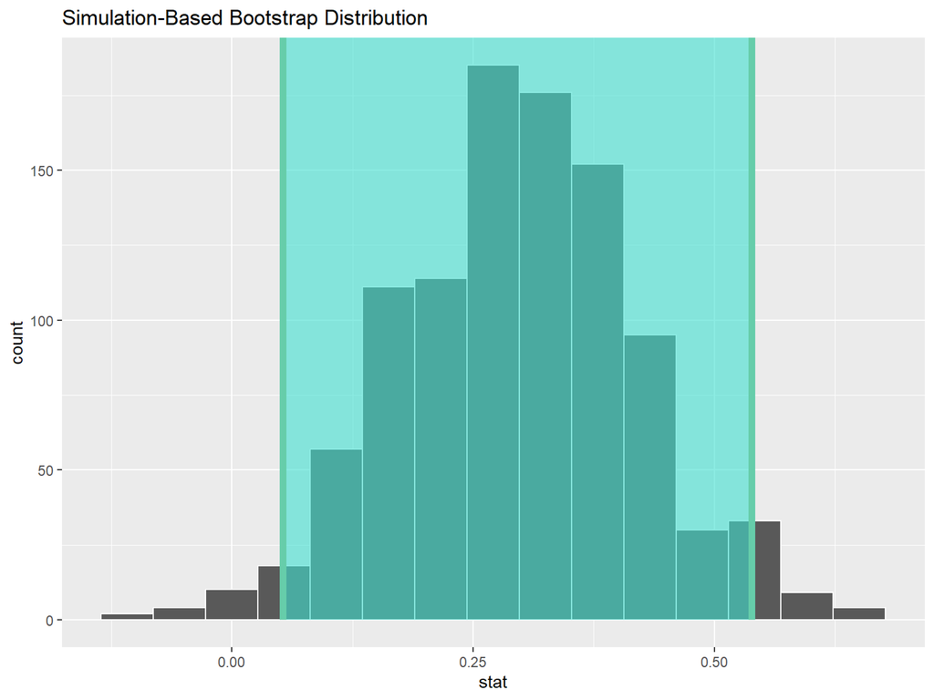

```r
visualize(bootstrap_distribution) +
  shade_confidence_interval(endpoints = percentile_ci)
```

Der Wert Null liegt nicht im 95%-Konfidenzintervall für die Differenz $p_m-p_f$. Dies legt nahe, dass die geschlechtsspezifischen Differenzen in Beförderungsquoten wirklich unterschiedlich sind. Aus der Tatsache, dass das gesamte 95%-Konfidenzintervall rechts von Null liegt, spricht dafür, dass die geschlechtsspezifischen Unterschiede zugunsten der Männer aufallen.

### Standardfehler-Ansatz

Weil die Bootstrap-Verteilung annähernd normalverteilt scheint, kann das Konfidenzintervall auch mittels Standardfehler konstruiert werden. Dazu müssen wir die Option *point_estimate = obs_diff_prop* noch in die `get_confidence_interval()`-Funktion einfügen, um das Zentrum des Konfidenzintervalls beim beobachteten Wert der Differenz (0.29) festzulagen.

```r
se_ci <- bootstrap_distribution %>%
                      get_confidence_interval(level = 0.95, type = "se",
                                              point_estimate = obs_diff_prop)
se_ci
```

```
## # A tibble: 1 × 2
##   lower_ci upper_ci
##      <dbl>    <dbl>
## 1   0.0544    0.529
```

- Visualisierung des mittels Standardfehler konstruierten 95%-Konfidenzintervalls für die Differenz $p_m-p_f$.

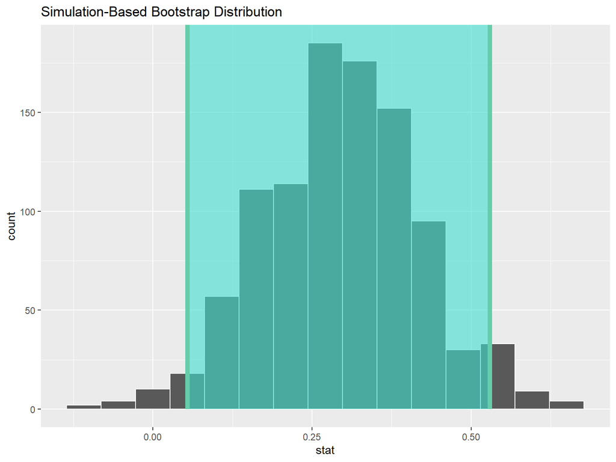

```r
visualize(bootstrap_distribution) +
        shade_confidence_interval(endpoints = se_ci)
```

- Auch in dem mittels Standardfehler konstruierten 95%-Konfidenzintervall ist die Null nicht enthalten. Mithin liegt auch hier der Schluss nahe, dass die geschlechtsspezifischen Unterschiede $p_m-p_f$ tatsächlich nicht zufällig sind.

# Es gibt nur einen Test

- Das **infer**-Paket setzt letzlich den [“There is only one test”](http://allendowney.blogspot.com/2016/06/there-is-still-only-one-test.html) Ansatz von Allen Downey um:

Grundsätzlich kann jeder Hypothesentest mit dem oben dargestellten workflow des **infer**-Pakets durchgeführt werden:

1. `specify()`: Spezifikation der interessierenden Variablen
2. `hypothesize()`: Formulierung der Null-Hypothese
3. `generate()`: Simulation von Daten unter der Annahme, dass $H_0$ wahr ist
4. `calculate()`: Berechnung der interessierenden (Anteile, Mittelwerte, Differenzene etc.) Teststatistik für beobachtete und simulierte Daten
5. `visualize()`: grafische Darstellung der Nullverteilung und Berechnung des p-Werts auf Basis des Vergleichs von beobachteten und simulierten Werten

**Interpretation von Hypothesentests**

# Kritischer Rationalismus

Damit haben wir (bezogen auf das vorab festgelegte Signifikanzniveau $\alpha=.05$) genügend Evidenz, um “$H_0$ auf dem 5%-Signifikanzniveau zu verwerfen”. Wir haben also genügend “Beweise” in den Daten gefunden, um festzustellen, dass geschlechtsspezifische Diskriminierung eine Rolle bei Beförderungen spielt.

- Entscheidung über Testausgang durch Vergleich von Signifikanzniveau $\alpha$ und $p$-Wert:
  - Wenn $p<\alpha$: $H_0$ wird zugunsten von $H_A$ verworfen.
  - Wenn $p\geq\alpha$: $H_0$ kann nicht verworfen werden (bzw. muss beibehalten werden).
- **statistische vs. praktische Signifikanz**:
  - klinische Studie zum Vergleich neuer medizinischer Behandlung mit Standardbehandlung
  - statistische Analyse zeigt statistisch signifikanten Unterschied in der Lebenserwartung bei Anwendung der neuen Behandlung.
  - Verlängerung der Lebenszeit beträgt höchstens drei Tage, im Durchschnitt weniger als 24 Stunden, die Lebensqualität während der verlängerten Lebenszeit ist schlecht.

Signifikanz vs. Effektstärke!

# Fehlerarten und Wahl des Signifikanzniveaus

- Wie wäre unsere Entscheidung zur Frage der Geschlechterdiskriminierung bei Beförderungen ausgefallen, hätten wir vorab (!) $\alpha=.01$ gesetzt?

### Fehlerarten

|  |  | Wahrheit/Realität $H_0$ korrekt | Wahrheit/Realität $H_0$ falsch |
| --- | --- | --- | --- |
| Entscheidung | $H_0$ beibehalten | richtige Entscheidung | Fehler 2. Art ($\beta$-Fehler) |
|  | $H_0$ verwerfen | Fehler 1. Art ($\alpha$-Fehler) | richtige Entscheidung |

- Fehler 1. Art:
  - Angeklagter wird zu Unrecht verurteilt.
  - Wir unterstellen zu Unrecht eine Geschlechterdiskriminierung bei Beförderungen.

$\alpha$ gibt die Wahrscheinlichkeit an, einen Fehler 1. Art zu begehen (die $H_0$ irrtümlich zu verwerfen). Je kleiner $\alpha$ vorab (!) gesetzt wird, umso geringer die Gefahr eines Fehlers 1. Art.

- Fehler 2. Art:
  - Angeklagter wird zu Unrecht freigesprochen.
  - Wir unterstellen zu Unrecht Fairness bei Beförderungen.

$\beta$ gibt die Wahrscheinlichkeit an, einen Fehler 2. Art zu begehen (die $H_0$ irrtümlich beizubehalten.

- **Teststärke** ($1-\beta$): Wahrscheinlichkeit, mit der ein statistischer Test zur Annahme einer wahren Alternativhypothese $H_A$ führt.

### Einordnung empirischer Ergebnisse

[video not shown]

### Wahl des Signifikanzniveaus

- Idealvorstellung: $\alpha=\beta=0$.
- Realität: Zielkonflikt $\alpha$ vs. $\beta$
- Gängige Praxis: $\alpha$ vorab (!) festlegen und versuchen, $\beta$ zu minimieren.
  - Typische Werte für $\alpha$: 0.1, 0.05, 0.01, 0.001
  - Je kleiner $\alpha$, “umso länger” wird die $H_0$ beibehalten (**konservativer Test**)
  - Je größer $\alpha$, “umso schneller” wird die $H_0$ verworfen (**liberaler Test**)

# Hypothesentests auf Basis theoretischer Verteilungen

- traditionelle Hypothesentests konstruieren die Nullverteilung nicht mittels Computersimulation (Resampling), weil die dafür notwendige “Rechenpower” erst seit kurzem verfügbar ist.
- stattdessen greifen traditionelle Hypothesentests auf **Wahrscheinlichkeitsmodelle**, **Wahrscheinlichkeitsverteilungen** und einige **Annahmen** zurück, um die Nullverteilung zu ermitteln.
- simulationsgestützte Methoden werden letztlich durch theoriegestützte Methoden approximiert. Formelbasierte, theoretische Ansätze als “Short-Cuts”.

### Annahmen im Fall von Unterschiedlichen Anteilen

1. Unabhängigkeit der Beobachtungen: Jeder ausgewählte Fall muss unabhängig von allen anderen ausgewählten Fällen sein;

die Bedingung ist im Beispiel erfüllt, da die Fälle nach dem Zufallsprinzip ausgewählt wurden.

2. Unabhängige Auswahl der Stichproben

Im Beispiel gibt es keinen Grund zu vermuten, dass ein ausgewählter Lebenslauf mit weiblichem Namen in irgendeiner Beziehung zu einem ausgewählten Lebenslauf mit männlichem Namen stehen würde.

3. Stichprobengröße: Die Anzahl der **gepoolten Erfolge und Misserfolge** muss **für jede Gruppe** mindestens 10 betragen

Ermittlung der gepoolten Erfolgsquote:

| gender | not | promoted |
| --- | --- | --- |
| male | 3 | 21 |
| female | 10 | 14 |

```r
z_hat <- promotions %>%
  observe(decision ~ gender, success = "promoted",
          stat = "z", order = c("female","male" ))
z_hat
```

```
## Response: decision (factor)
## Explanatory: gender (factor)
## # A tibble: 1 × 1
##    stat
##   <dbl>
## 1 -2.27
```

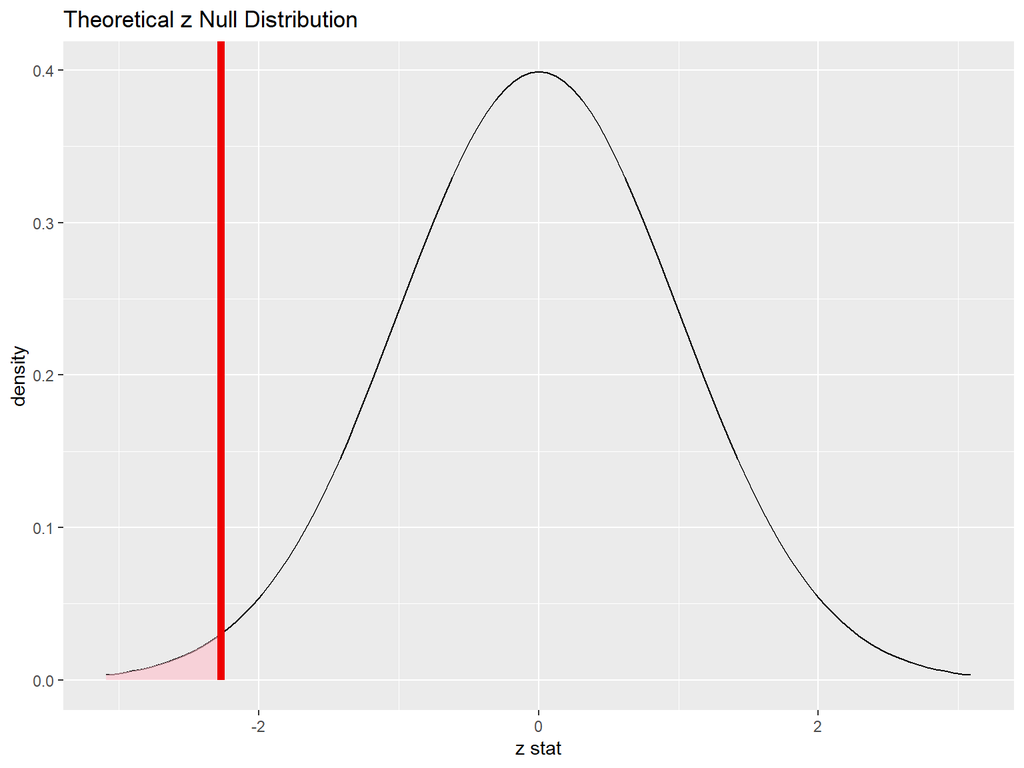

```r
null_dist_theory <- promotions %>%
  specify(decision ~ gender, success = "promoted") %>%
  assume("z")

visualize(null_dist_theory) +
  shade_p_value(obs_stat = z_hat, direction = "less")
```

```r
prop_test(promotions,
          decision ~ gender,
          order = c("female", "male"),
          alternative = "greater")
```

```
## # A tibble: 1 × 6
##   statistic chisq_df p_value alternative lower_ci upper_ci
##       <dbl>    <dbl>   <dbl> <chr>          <dbl>    <dbl>
## 1      3.80        1  0.0257 greater       0.0809        1
```

**Fazit und Ausblick**

# Mind Map zur “Test-Navigation”

[interactive chart not shown]

Inferenz Mind Map

# Wann sind Tests überflüssig?